# Stat_Inference_CourseProj

Part 1

```r
set.seed(10)
nosim <- 1000
simu<-rexp(nosim*40, 0.2)   # generate simulation 1000x40 values
values<-matrix(simu, nosim) # put these values in matrix 1000 rows by 40 columns
means<-apply(values, 1, mean) # apply mean to each row (1 for row)

Smean<-mean(means) # sample mean
Svar<-var(means)   # sample variance

#Exponential Distribution, rexp(n,lambda) with lambda=0.2
#Theoretical mean = 1/lambda=1/0.2 = 5
#Theoretical standard deviation = 1/lambda = 1/0.2=5
#Theoretical variance = sd^2=5^2=25
```

Question#1: Sample mean = 5.0450596, and theoretical mean=5

Question#2: Sample variance=0.6541736, and theoretical variance=25

As Central Limit Theorem states giving a distribution with a mean of mu and variance of sigma^2, the sampling distriubtion of the mean approaches a normal distribution with a mean (mu) and a variance sigma^2/N. Therefore, in this exercise, the sample mean is close to theoretical population mean, and variance of the sampling distribution of the mean is close to sigma^2/N (=5^2/40=0.625).

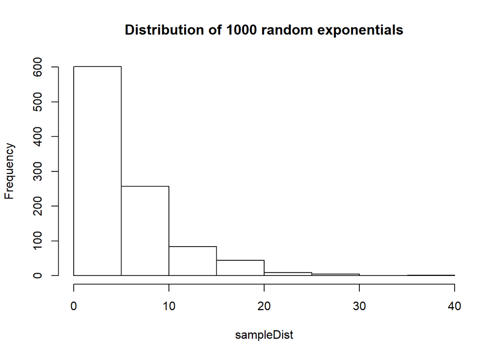

```r
# Distribution of a large collection of random exponentials (1000 samples)

sampleDist<-rexp(1000, 0.2)
hist(sampleDist, main="Distribution of 1000 random exponentials")
```

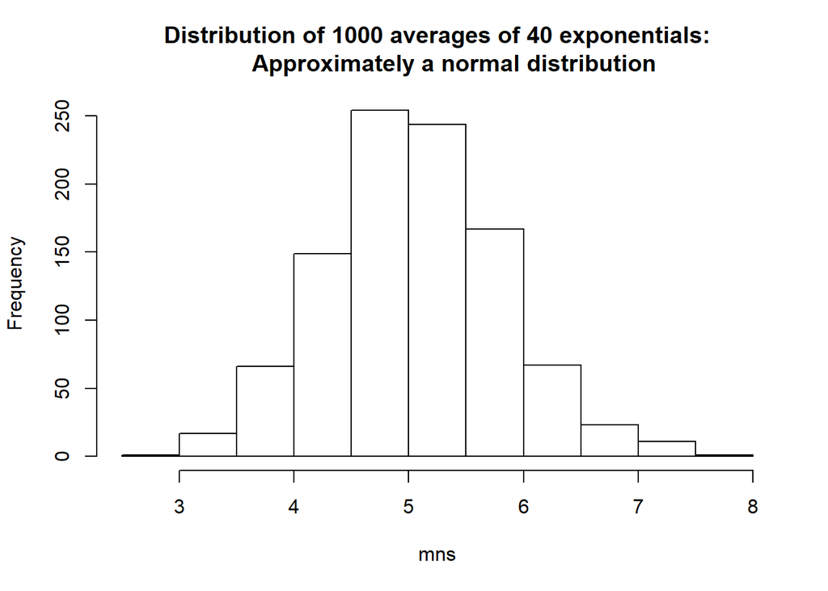

```r
# Distribution of a large collection (1000 samples) of averages of 40 exponentials

mns=NULL
for (i in 1:1000) mns=c(mns, mean(rexp(40, 0.2)))
hist(mns, main="Distribution of 1000 averages of 40 exponentials:
     Approximately a normal distribution")
```

Question#3: The distribution of the average of 40 exponentials is approximately normal, because, the graph looks symmetrical centering at mean of 5.

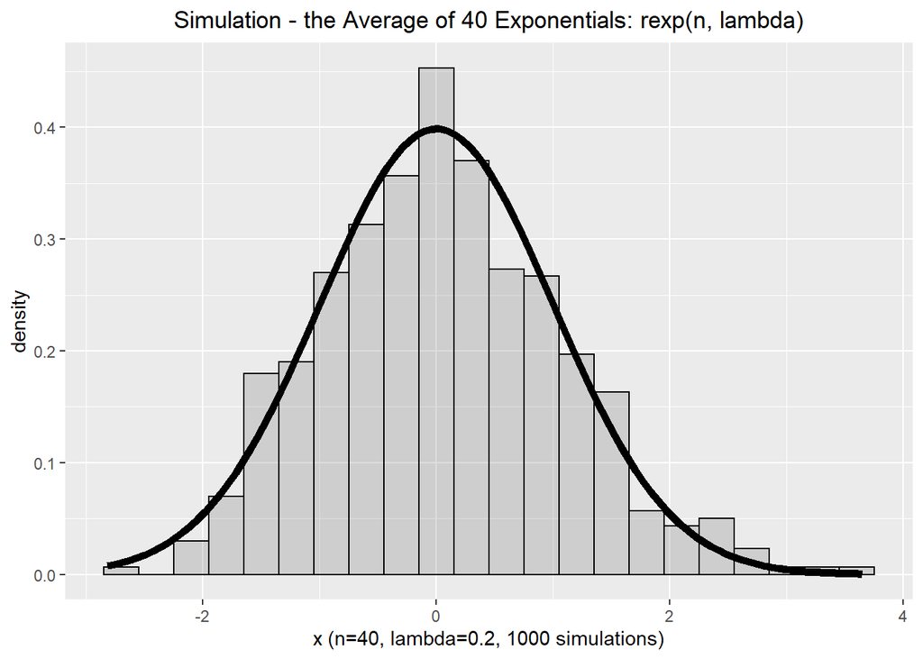

```r
cfunc <- function(x, n) sqrt(n)*(mean(x)-5)/5  # (x-mu)/(sigma/sqrt(n))
dat <- data.frame(x = apply(values, 1, cfunc, 40))

g <- ggplot(dat, aes(x = x)) + geom_histogram(alpha = .20,
    binwidth=0.3, colour = "black", aes(y = ..density..))
g + stat_function(fun = dnorm, size = 2)+labs(title="Simulation - the Average of 40 Exponentials: rexp(n, lambda)", x="x (n=40, lambda=0.2, 1000 simulations)")+theme(plot.title=element_text(hjust=0.5))
```

Part 2

```r
#Question#1: load data ToothGrowth"

data("ToothGrowth")
dim(ToothGrowth)
```

```
## [1] 60  3
```

```r
str(ToothGrowth)
```

```
## 'data.frame':    60 obs. of  3 variables:
##  $ len : num  4.2 11.5 7.3 5.8 6.4 10 11.2 11.2 5.2 7 ...
##  $ supp: Factor w/ 2 levels "OJ","VC": 2 2 2 2 2 2 2 2 2 2 ...
##  $ dose: num  0.5 0.5 0.5 0.5 0.5 0.5 0.5 0.5 0.5 0.5 ...
```

```r
unique(ToothGrowth$dose)
```

```
## [1] 0.5 1.0 2.0
```

Question#2: Summary of data - ToothGrowth dataset has 60 rows (or observations) and 3 columns (or variables). The variables are len (number variable), supp (factor variable with 2 level: OJ and VC), and dose (number variable with unique value of 0.5, 1.0, and 2.0)

```r
g1<-ToothGrowth$len[1:30]; g2<-ToothGrowth$len[31:60]
t.test(g1,g2, paired=FALSE)$conf
```

```
## [1] -7.5710156  0.1710156
## attr(,"conf.level")
## [1] 0.95
```

Question#3 & 4: Compare tooth growth by supp using t-test above - At 95% confidence level, the difference in mean between OJ group and VC group is not significant. The 95% confidence interval includes 0.

```r
low<-ToothGrowth$len[ToothGrowth$dose==0.5]
mid<-ToothGrowth$len[ToothGrowth$dose==1]
high<-ToothGrowth$len[ToothGrowth$dose==2]

t.test(mid,low)$conf; t.test(high, low)$conf; t.test(high, mid)$conf
```

```
## [1]  6.276219 11.983781
## attr(,"conf.level")
## [1] 0.95
```

```
## [1] 12.83383 18.15617
## attr(,"conf.level")
## [1] 0.95
```

```
## [1] 3.733519 8.996481
## attr(,"conf.level")
## [1] 0.95
```

Question#3 & 4: Compare toothgrowth by dose using t-test above - The dose has an effect on tooth growth. The T test of the 3-dosage groups shows that the confidence intervals do not include 0, meaning that the mean tooth growth in each group is statistically different from the other groups at 95% confidence level.